# hw_3_pop_gen

Mrinal Vashisth

12/11/2019

```r
library(dplyr)
library(reshape2)
library(tidyr)
```

```r
library(ggplot2)
```

# Solution 1

a 012345 AGCTAA AGCTCC AGGTAG AGCTCT AACTAC

EHH[0] = 5*(5-1)/ 20 = 1 EHH[01] = 4*3 / 20 = 0.6 EHH[012] = 3*2 / 20 = 0.3 EHH[0123] = 3*2 = 0.3 EHH[01234] = 2*1 / 20 = 0.1 EHH[012345] = 0

A 012345 GAGTGA GTCCAA GACTGA GTGCAA GAACAA

EHH[0] = 5*(5-1)/ 20 = 1 EHH[01] = 3*(3-1) + 2*(2-1) / 20 = 0.4 EHH[012] = 0 EHH[0123] = 0 EHH[01234] = 0 EHH[012345] = 0

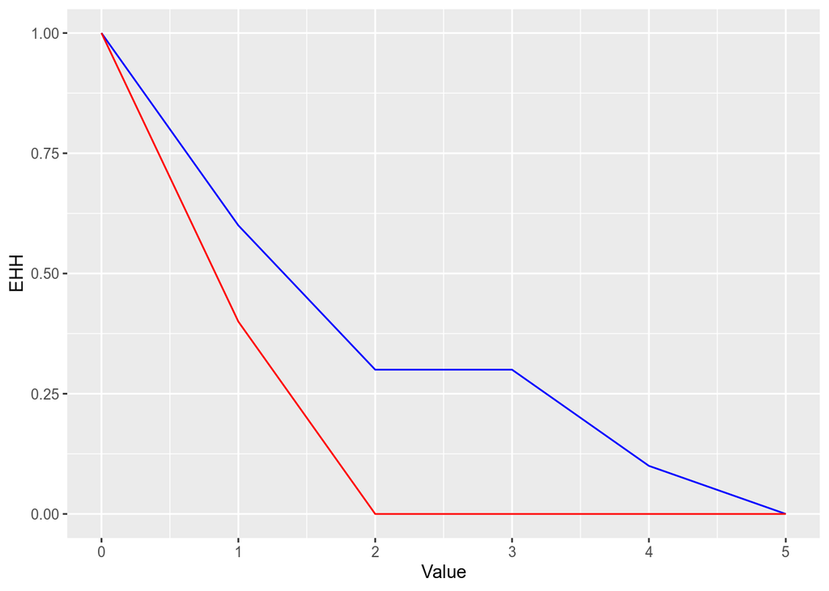

```r
ehh_1 <- c(1, 0.6, 0.3, 0.3, 0.1, 0)
ehh_2 <- c(1, 0.4, 0, 0, 0, 0)
pos <- c(0, 1, 2, 3, 4, 5)
ehh <- data.frame(ehh_1, ehh_2, pos)

p <- ggplot() +
  geom_line(data = ehh, aes(x = pos, y = ehh_1), color = "blue") +
  geom_line(data = ehh, aes(x = pos, y = ehh_2), color = "red") +
  xlab('Value') +
  ylab('EHH')

p
```

We know that, for alleles under selection, EHH will decrease slower. In our case allele ‘a’ is under positive selection.

# Solution 2

I selected PAX6 gene which is involved in neural development.

The pLI for this gene is 1! The closer pLI is to one, the more intolerant of protein-truncating variants the transcript appears to be. We consider pLI ≥ 0.9 as an extremely intolerant set of transcripts.

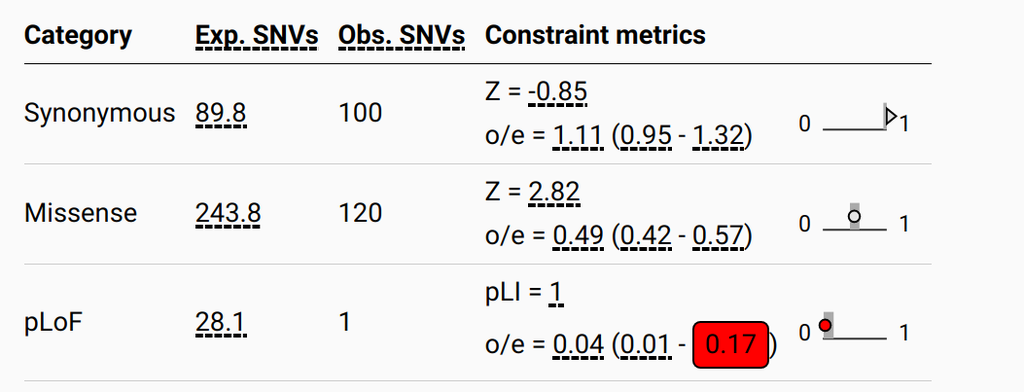

image

# Solution 3

```r
ESP_SNP_data <- data.frame(read.delim("~/Desktop/pop_gen_hws/hw_3/ESP_SNP_data.tsv"))
df <-ESP_SNP_data
df$LOC <- NULL
unique(ESP_SNP_data$EFF)
```

```
## [1] NON_SYNONYMOUS_CODING SYNONYMOUS_CODING     STOP_GAINED
## Levels: NON_SYNONYMOUS_CODING STOP_GAINED SYNONYMOUS_CODING
```

So we have Three levels for EFF (effect).

Stop gained is technically non-synonymous.

```r
df$EFF <- gsub("STOP_GAINED", "NON_SYNONYMOUS_CODING", df$EFF)
df$EFF <- gsub("NON_SYNONYMOUS_CODING", "NON_SYNONYMOUS", df$EFF)
df$EFF <- gsub("SYNONYMOUS_CODING", "SYNONYMOUS", df$EFF)

# Let's get all synonymous and non synonymous statistics
new <- df %>%
  group_by(GENE, EFF) %>%
  summarise_all(sum)
```

```r
# Let's drop genes which do not have synonymous mutations
# the logic is that such column should contain factors for EFF greater than 1, i.e. they will have both SYN and NON_SYN levels, and any GENE having SYN/ NON_SYN alone should be dropped

# At first collapse each gene into one row with two effects
# Remove all NAs
# Then create new column with statistcs nonsyn/syn

new_wide <- spread(new, EFF, AF)
# remove NAs
new_wide <- new_wide %>% drop_na()
summary(new_wide)
```

```
##       GENE       NON_SYNONYMOUS       SYNONYMOUS
##  A1BG   :    1   Min.   : 0.00008   Min.   : 0.000077
##  A1CF   :    1   1st Qu.: 0.00769   1st Qu.: 0.013071
##  A2M    :    1   Median : 0.05079   Median : 0.106259
##  A2ML1  :    1   Mean   : 0.35213   Mean   : 0.415396
##  A3GALT2:    1   3rd Qu.: 0.41519   3rd Qu.: 0.580381
##  A4GALT :    1   Max.   :32.03639   Max.   :15.383413
##  (Other):18309
```

Now we are ready to perform some statistics!

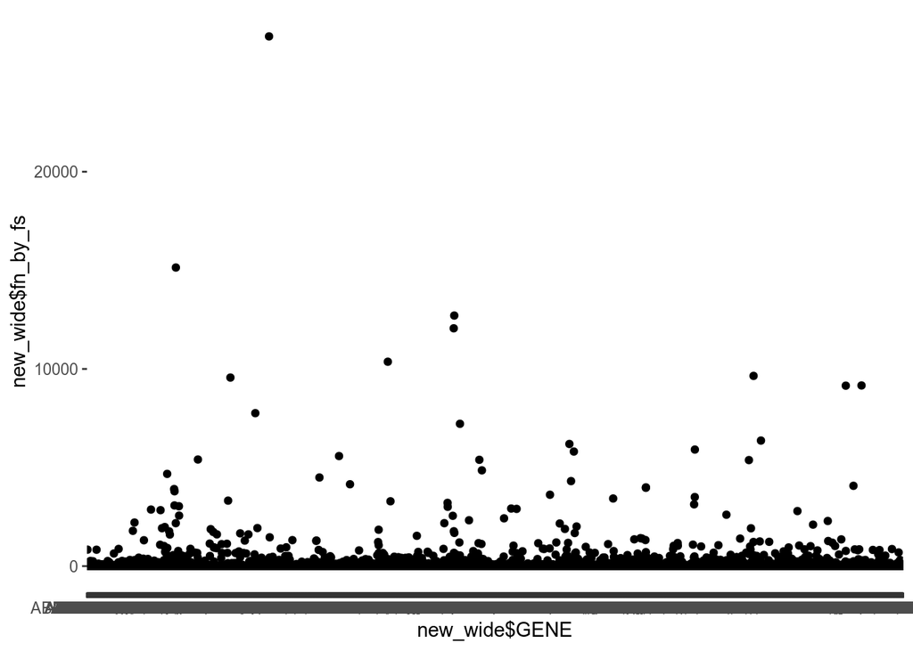

```r
new_wide$fn_by_fs <- new_wide$NON_SYNONYMOUS/new_wide$SYNONYMOUS

#pdf("/home/mrinalmanu/Desktop/pop_gen_hws/hw_3/rplot.pdf")
qplot(new_wide$GENE, new_wide$fn_by_fs, geom=c("point"))
```

```r
#dev.off()
```

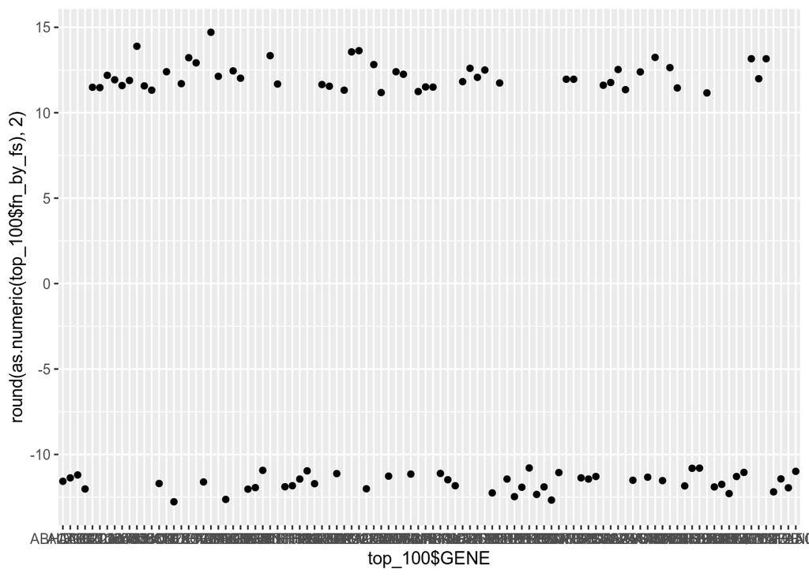

```r
#sort by mpg (ascending) and cyl (descending)
newdata <- new_wide[order(new_wide$fn_by_fs),]
top_100 <- rbind(head(newdata, 50), tail(newdata, 50))

top_100$NON_SYNONYMOUS <- NULL
top_100$SYNONYMOUS <- NULL
top_100$fn_by_fs <- format(top_100$fn_by_fs, scientific = FALSE)
top_100$fn_by_fs <- log2(as.numeric(top_100$fn_by_fs))

qplot(top_100$GENE, round(as.numeric(top_100$fn_by_fs), 2), geom=c("point"))
```

Searching for following genes.

CFL1,PSMA7,FAM228B,POU3F2,PPP3R1,UBALD2,PDIK1L,YAF2,GNG8,ARF3,KRTAP7-1,YWHAG,GPR85,PPP1CB,TSPAN13,PRIMA1,HIST1H3C,TMEM233,HIST1H3I,NOVA2,TUBB2A,ING2,CBLN2,DDX39B,ABHD17C,SRSF2,SLC25A5,NIPA1,POLR2L,HIST1H4H,RBBP4,YPEL5,ACTG1,PURB,SPANXN5,RPS16,UBE2Z,LSM5,AGO2,MAGOHB,KRAS,NAP1L1,PSMC2,UFM1,ZFAND5,HSPA8,GSX1,TMEM253,TNFSF12,PPP1CC,TSEN15,LOC401052,MLN,KRTAP12-3C8orf4,SLC25A45,TM4SF19,BTLA,BCL2L10,MT1A,MRPL18,KLRD1,C8orf31,C2orf83,S100A7,KLRC1,HINT3,CLEC1B,PLA2G2C,SAA2,NPW,C2orf88,C2orf70,PSMG4,PSORS1C2,VMO1,GAGE12J,OR4F5,FAM180B,C17orf58,MAGEB16,SPAG11A,LYRM4,CCL15,FMC1,OR52N4,SAA4,OR2T5,ST20,LCE5A,CXCL11,UQCC3,WFDC10B,CLPSL2,SPINK6,HEPN1,KRTAP22-1,KRTAP4-2,C4orf36,DEFB108B

CORRECTIONS

mean fn/fs

```r
mean(new_wide$fn_by_fs)
```

```
## [1] 35.43401
```

top 100 and bottom 100 together

```r
new_wide$fn_by_fs <- format(new_wide$fn_by_fs, scientific = FALSE)
newdata <- data.frame(new_wide[order(new_wide$fn_by_fs),])

x <- newdata[order(newdata$fn_by_fs),]
top_100 <- tail(x, n=100)
bottom_100 <- head(x, n =100)
head(top_100)
```

```
##          GENE NON_SYNONYMOUS   SYNONYMOUS         fn_by_fs
## 18216  CLDN19      0.2618056 0.0002306630  1135.0134182769
## 18217    CDK7      0.6155620 0.0005383192  1143.4889309168
## 18218 NEUROG3      0.6259812 0.0005383668  1162.7411759046
## 18219    LY96      0.9863870 0.0008459651  1165.9901497118
## 18220  RNASE3      0.6322220 0.0005392438  1172.4232252647
## 18221   OR2G2      1.5418270 0.0013070890  1179.5883789092
```

```r
head(bottom_100)
```

```
##      GENE NON_SYNONYMOUS SYNONYMOUS         fn_by_fs
## 1    CFL1   0.0000769468  0.5387810     0.0001428165
## 2   PSMA7   0.0002306628  1.5044215     0.0001533233
## 3 FAM228B   0.0002190100  1.3885237     0.0001577287
## 4  POU3F2   0.0001562874  0.8853077     0.0001765346
## 5  PPP3R1   0.0000814465  0.4226882     0.0001926869
## 6  UBALD2   0.0001569446  0.7838054     0.0002002342
```

```r
head(top_100$GENE)
```

```
## [1] CLDN19  CDK7    NEUROG3 LY96    RNASE3  OR2G2
## 18571 Levels: A1BG A1CF A2M A2ML1 A3GALT2 A4GALT A4GNT AAAS AACS ... ZZZ3
```

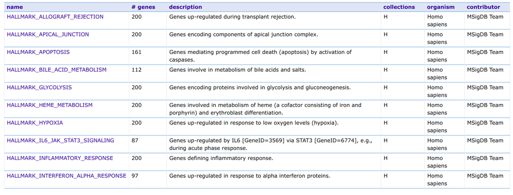

image

```r
head(bottom_100$GENE)
```

```
## [1] CFL1    PSMA7   FAM228B POU3F2  PPP3R1  UBALD2
## 18571 Levels: A1BG A1CF A2M A2ML1 A3GALT2 A4GALT A4GNT AAAS AACS ... ZZZ3
```

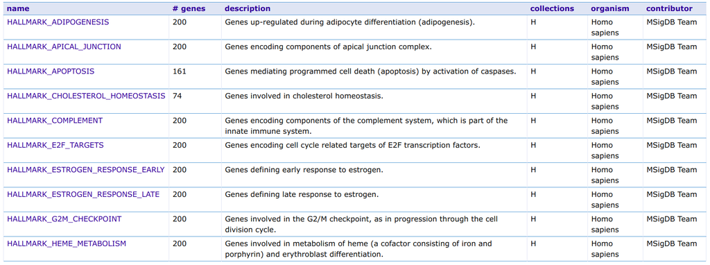

image